# ECO 701: Midterm Exam Summary & Grading Policy

Midterm exams have been graded and will be returned in class. I’ve graded these on a curve. Below is a summary of the class distribution on the raw scores, the curved letter-grade scale, and an important policy on how you can improve your midterm standing on the final exam.

## 1. Raw Score Descriptive Statistics ($n = 18$)

| Statistic | Value |
| --- | --- |
| **Mean** | 72.3 |
| **Median** | 72.3 |
| **Standard Deviation** | 15.7 |
| **Minimum** | 45.0 |
| **25th Percentile ($Q_1$)** | 58.1 |
| **75th Percentile ($Q_3$)** | 87.0 |
| **Interquartile Range (IQR)** | 28.9 |
| **Maximum** | 97.5 |

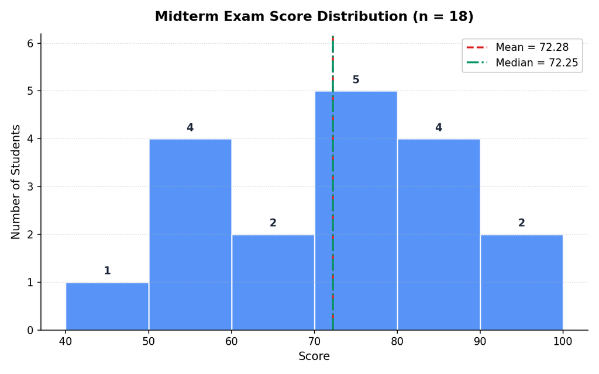

Midterm Exam Score Distribution

## 2. Curved Letter-Grade Distribution

Because students enter this master’s program with varied mathematical and economics backgrounds, I have applied a **very generous curve** to this midterm. Cutoffs were placed at natural breaks in the score distribution so that no one was penalized by a fraction of a point, and no grades below a C- were assigned.

| Letter Grade | Raw Score Range | Number of Students | Share of Class |
| --- | --- | --- | --- |
| **A** | 93.0 – 100.0 | 2 | 11.1% |
| **A-** | 87.0 – 92.9 | 3 | 16.7% |
| **B+** | 80.0 – 86.9 | 1 | 5.6% |
| **B** | 68.0 – 79.9 | 6 | 33.3% |
| **C+** | 60.0 – 67.9 | 1 | 5.6% |
| **C** | 50.0 – 59.9 | 4 | 22.2% |
| **C-** | Below 50.0 | 1 | 5.6% |
| **Total** |  | **18** | **100%** |

- **B or higher:** 12 students (66.7%)
- **C+ or lower:** 6 students (33.3%)

## 3. An Important Wake-Up Call

While the letter-grade curve above is deliberately forgiving, **anyone who scored under an 80 on the raw exam should treat this result as an important wake-up call**. In a master’s program, a raw score in the 50s, 60s, or low 70s indicates gaps in core material that will be essential as we move into the second half of the course, and you move onto other classes.

If you scored below 80, please review the posted solutions very carefully (the exam was not hard if you notice the many tricks along the way). Rework the problems you missed, and reach out to me to arrange to talk during office hours or an arranged meeting. It’s better to address this sooner than later.

If you obtained a low score, do not despair. Students have entered this MA program before with a wide dispersion of experience and preparation. Many students who stumbled early in this class have been able to turn things around and succeed in the program and their careers. Everyone in this class is capable of turning this around.

## 4. Opportunity to Improve Your Midterm Grade via the Final Exam

Under the course syllabus, your exam grade is already weighted **45%** on your higher exam score and **30%** on your lower exam score (with the remaining **25%** from problem sets and participation). To give students who struggled on the midterm an even stronger incentive to catch up, I am adding a **final-exam replacement policy** on top of the syllabus rule:

> **If you score higher on the final exam than you did on the midterm, I will replace your midterm score with the simple (50/50) average of your midterm and final exam scores before applying the 45% / 30% syllabus weights.**

Effectively, when your final exceeds your midterm, this shifts the course weights from 30% midterm / 45% final to **15% midterm / 60% final** (plus 25% for problem sets and participation).

**Example:** Suppose you earned a **48** on the midterm, earn an **84** on the final exam, and have a **100** average on problem sets and participation:

1. Your midterm score is replaced with $\frac{48 + 84}{2} = \mathbf{66}$.
2. Applying the syllabus weights gives a weighted exam average of $\frac{0.45(84) + 0.30(66)}{0.75} = \mathbf{76.8}$ (up from $69.6$ without replacement), and a total course score of:
   $$0.45(84) + 0.30(66) + 0.25(100) = 37.8 + 19.8 + 25.0 = \mathbf{82.6}$$

*(If your final exam score is lower than your midterm score, no replacement is applied and the standard syllabus rule—45% midterm, 30% final—stands. This policy can only help you.)*